QRM: Seventh Meeting

# Research Methodology in Social Sciences

Dr. David Sichinava  
November 30, 2018

Seventh Meeting

### Today's meeting

- Correlation

### How do we assess relationship between two variables?

- The simplest way to examine relationship between two variables is to check whether they *covary*,
  - That is, whether they change simultaneously
- Covariance coefficient can be measured as follows:
  - \( cov(x, y) = \frac{\sum(x_{i}-\bar{x})(y_{i}-\bar{y})}{N-1} \)

### How do we assess relationship between two variables?

- As you might notice, covariance measurement depends on the *scale* of variables, therefore we should *standardize* coefficients
- Here we should include standard deviations for both variables as follows:
  - \( cov(x, y) = \frac{\sum(x_{i}-\bar{x})(y_{i}-\bar{y})}{(N-1)s_{x}s_{y}} \)

### Types of correlations

- Bivariate: examines the relationship between two variables
- Partial: examines relationship between two variables while *controlling* for the effect of other variable
  - In this case, we have to assess the impact moderating variable has on correlation coefficients

### Types of correlation: distribution is crucial

- Spearman's rho
- Kendall's tau
  - Small population with multiple ranked variables

### Correlation vs. Causation

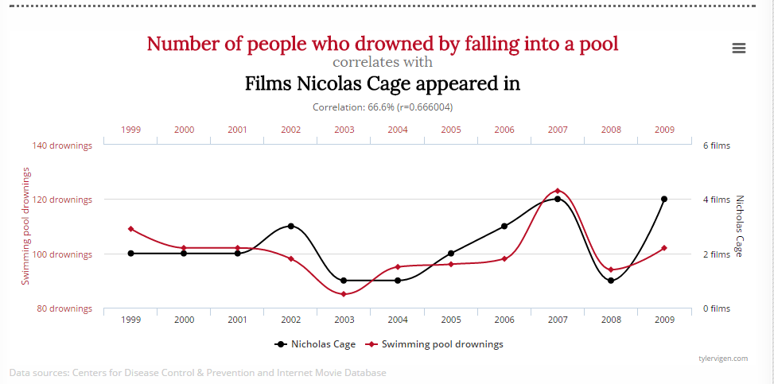

### Correlation vs. Causation

[figure not shown]

### Factor analysis

- Often we have to deal with *latent* variables, that is phenomena which cannot be measured directly
- Put it simple, calculating correlations between variables might yield *clusters* of variables
  - Therefore, variables which are highly correlated which might be measuring same latent concept

### Factor analysis

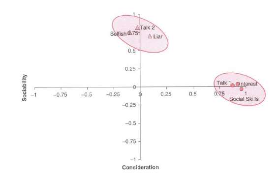

### Factor analysis

- It is not neccessary to retain all factors to our analysis
- Examine so called *scree plot*
- In order to improve the quality of your factor analysis by *rotating factors*